# Plant diversity and functional identity alter ant occurrence and activity in experimental grasslands - Achury - 2022 - Ecosphere - Wiley Online Library

[Ecosphere](https://esajournals.onlinelibrary.wiley.com/journal/21508925)

[Volume 13, Issue 10](https://esajournals.onlinelibrary.wiley.com/toc/21508925/2022/13/10) e4252

[figure not shown]

ARTICLE

Open Access

# Plant diversity and functional identity alter ant occurrence and activity in experimental grasslands

[Rafael Achury](https://esajournals.onlinelibrary.wiley.com/action/doSearch?ContribAuthorRaw=Achury%2C+Rafael),

[Lars Clement](https://esajournals.onlinelibrary.wiley.com/action/doSearch?ContribAuthorRaw=Clement%2C+Lars),

[Anne Ebeling](https://esajournals.onlinelibrary.wiley.com/action/doSearch?ContribAuthorRaw=Ebeling%2C+Anne),

[Sebastian Meyer](https://esajournals.onlinelibrary.wiley.com/action/doSearch?ContribAuthorRaw=Meyer%2C+Sebastian),

[Winfried Voigt](https://esajournals.onlinelibrary.wiley.com/action/doSearch?ContribAuthorRaw=Voigt%2C+Winfried),

[Wolfgang W. Weisser](https://esajournals.onlinelibrary.wiley.com/action/doSearch?ContribAuthorRaw=Weisser%2C+Wolfgang+W),

First published: 04 October 2022

https://doi.org/10.1002/ecs2.4252

**Handling Editor:** Debra P. C. Peters

**Funding information** Deutsche Forschungsgemeinschaft

## INTRODUCTION

The strong decrease in worldwide biodiversity has generated increased interest in the consequences of a loss of diversity in animal groups important for ecosystem processes (Cardinale et al., 2012; Tilman et al., 2001; Weisser et al., 2017). For a number of experimental ecosystems, in particular artificially assembled plant communities, there is now a wealth of studies showing that decreasing plant biodiversity can have negative effects on the number of species mediating processes at the ecosystem level (Barnes et al., 2020; Buzhdygan et al., 2020; Wang et al., 2021). However, the mechanisms underlying the observed relationship between plant diversity and the activity of animals are often unclear. While plant functional composition may be an important reason why plant communities of increasing diversity support, for example, more trophic levels or specialized communities with different foraging strategies (Ebeling, Rzanny, et al., 2018; Scherber et al., 2010), in other cases the effect of plant diversity on biodiversity is likely to be related with the physical structure of plant communities (Schuldt et al., 2019). For example, many arthropod groups important in ecosystem function respond differentially to changes in the spatial distribution and complexity of habitats and microclimates (Hertzog, Meyer, et al., 2016; Langellotto & Denno, 2004). Thus, understanding the response of ecologically dominant taxa to a change in plant diversity is important for a mechanistic understanding of how plant diversity affects the diversity of organisms other than plants, and their potential consequences in ecosystem function.

Ants (Hymenoptera: Formicidae) are an interesting group to address this type of relationship, because they are numerically and ecologically dominant worldwide (Hölldobler & Wilson, 1990), making up an average of 15%–20% of animal biomass among terrestrial ecosystems (Schultz, 2000). Moreover, ants when acting as predators play key roles by altering the composition of arthropods foraging on soil (Hertzog et al., 2017; Moya-Larano & Wise, 2007; Philpott & Armbrecht, 2006). Ant nests emit high amounts of CO<sub>2</sub> and are therefore spots of high metabolic activity (Risch et al., 2005). In many plant communities, ants are important seed dispersers affecting the distribution of plant species (Prior et al., 2020), and many ant species form mutualistic relationships with plants and myrmecophilous insects, altering the distribution of the species connected within these ecological networks (Ness et al., 2010). With their stationary and perennial colonies, which restrict the activity and foraging of workers to an area close to the nest (Blüthgen & Feldhaar, 2010), ants have relatively constant populations at a site and can thus be reliably monitored and easily sampled in a standardized way, which makes them established indicator organisms (Alonso, 2000). However, little is known about the responses of ant assemblages to experimental manipulation of plant diversity.

Although the distribution, abundance, and species richness of ants have been studied extensively around the world, tropical and Australian ecosystems are relatively better known both qualitatively and quantitatively (Blüthgen et al., 2000; Lassau & Hochuli, 2004; Silva & Brandão, 2010). In the latter regions, factors such as the temperature regime (Retana & Cerdá, 2000), frequency of disturbances (e.g., fires or grazing) (Bestelmeyer & Wiens, 1996; Parr & Andersen, 2008), and plant composition (Dunn, 2004) have been demonstrated to be important in structuring ant communities. Particularly, the effects of plant composition on ants can act through influences on microclimate, soil type, or resource availability (Philpott et al., 2010). For example, ants are constrained like most ectotherms by temperature (Kaspari et al., 2019; Roeder et al., 2021), and different plant functional groups (FGs) can lead to a decrease in temperature, which might reduce general activity, foraging time, and reproductive success by imposing physiological limitations on ants (Sanders et al., 2007). In contrast, temperate habitats, with their comparatively species-poor ant communities, have been subject to less research and little is known about mechanisms structuring ant assemblages other than in forests (Dauber & Wolters, 2005, Floren et al., 2014, Grevé et al., 2018; but see Wills & Landis, 2018). Even though it is known that different ant species are associated with different vegetation types (Kumschick et al., 2009), the question of how gradients in plant diversity affect ant occurrence has not been studied.

Here, we investigate the effects of plant species richness on the abundance, activity, and diversity of ants in the context of European grassland, an ecosystem where ants are abundant and act as ecosystem engineers (Lavelle et al., 2006). We studied the occurrence and activity of ants in the framework of a plant species richness gradient from 1 to 60 species in the Jena grassland biodiversity Experiment (Roscher et al., 2004; Weisser et al., 2017), using a wide array of methods. In addition to the effects of plant species richness, we investigate the effects of plant functional diversity and the presence of particular plant FGs such as legumes on ant occurrence. Specifically, we used ant community composition measured in an experimental approach to investigate the following general questions: (1) Is there an effect of plant species richness on ant diversity, abundance, and general patterns of foraging (i.e., activity)? (2) Does plant functional diversity influence ant occurrence in these grasslands? (3) Is there a differential response by ants to different FGs of plants?

## METHODS

### General experimental design

Our experimental approach used the setup of the Jena Experiment (for details on the experimental design, see Roscher et al., 2004), where 82 experimental grassland plots 20 × 20 m in size were established at a field site located on the floodplain of the Saale River (altitude 130 m) at the northern edge of Jena (Germany). The field was previously used for arable crops before establishment of the experimental plots with plant communities representing various plant diversity treatments. The species pool consisted of 60 herbaceous plant species commonly occurring in the region surrounding the field site. Plant species were divided into four FGs: *grasses*, *legumes*, *small herbs*, and *tall herbs* using cluster analysis of a trait matrix (for details see Roscher et al., 2004). The Jena Experiment was planned as a factorial design in which several combinations of plant species richness and FGs are evaluated simultaneously. The plots were seeded with 1, 2, 4, 8, 16, or all 60 species containing 1, 2, 3, or 4 FG in May 2002. Species to be used in monocultures and mixtures were selected randomly with replacement from the pool, ensuring that all possible combinations of species richness and number of FG occurred in the experiment. This yielded 16 replicates for monocultures (1 FG), 16 for 2-species mixtures (1–2 FG), 16 for 4-species mixtures (1–4 FG), 16 for 8-species mixtures (1–4 FG), 14 for the 16-species mixtures (1–4 FG, except for the “16 species × 1 FG” combination, because fewer than 16 species of legumes and small herbs were available), and 4 replicates for the 60-species mixture (Roscher et al., 2004). The 82 plots were grouped into four blocks to account for gradients in abiotic conditions with increasing distance from the Saale River (mainly soil sand content; Roscher et al., 2004). All experimental communities were manually weeded twice per year to maintain the given diversity treatments, and correspondingly mown twice a year. For our experiment, we used two 2 × 4 m areas designated for work on insects along one side of each plot.

Soil temperature and relative air humidity were measured daily in every individual plot during the years of collection. Plant biomass was harvested at the end of May and at the end of August in 2005 and 2006, by cutting the plant material 3 cm above soil surface in four randomly 20 × 50 cm squares located within plots. The plant material collected was then oven-dried at 70°C for 48 h and weighed. Soil temperature was measured daily between 2005 and 2006 every hour using a PT100 resistance thermometer located in the soil at 5 cm depth. Air humidity was measured each hour per day for 2005 and 2006 at 30 cm above ground level, but this measure only took place in block II of the experiment (Weigelt et al., 2010). Data were transported to a central computer using a CAN bus logger system (Weisser et al., 2017).

### Ant survey

We sampled ants in three different ways. First, for obtaining data on assemblage structure, specifically the number and the abundance of epigeal ant species, we used pitfall traps. Pitfall trapping is an effective and commonly employed method for sampling ant communities and provides useful information regarding ant foraging patterns and abundance of ant foragers (Bestelmeyer et al., 2000). Two traps of 9.0 cm diameter were placed centrally at a distance of 2 m in plots with a plant species richness of 1, 4, 16, and 60. Pitfall traps consisted of a plastic container filled with a formalin solution and were placed with their rims flush with the surrounding soil. This sampling was carried out in 2005 and in each evaluated plot both traps were displayed on 9 May and emptied six times every three weeks until 12 October. After traps were removed from the plots, we identified and counted all ants.

Second, we counted the number of colonies within each plot in an area of 4 m<sup>2</sup>, by searching carefully for entrance holes in the soil as a measure of colony number. Colonies were mapped during 2006 (from 4 July to 16 August) in 81 plots with a plant species richness of 1, 2, 4, 8, 16, and 60. One plot with monoculture had to be excluded, as we did not have measurements for some of the covariates (see *Statistical analysis*). An entrance was identified when ants were observed entering the nest and also by following recruiting ants returning to their nest after small disturbances using forceps.

Finally, we used baiting experiments with two different baits, sugar and tuna, to acquire information on ant activity by trophic generalist ants, and to examine the time needed for these species to exploit the bait, that is, time of discovering. Baiting experiments are used to approximate ephemeral protein, lipid, and carbohydrate resources such as carrion, large dead insects, or nectar. While baits may bias estimates of community composition, particularly by excluding dietary specialists (Bestelmeyer et al., 2000), they are widely used in studies of ant community ecology yielding information about ant resource use (Achury et al., 2020). Although the nutrient composition of the bait does not significantly affect the ant composition visiting these resources (Bestelmeyer et al., 2000), volatiles are important for ant attraction, resulting, for example, in lower levels of attraction for pure sugar baits that emit little or no volatiles compared with the highly odorous tuna baits.

In 2006, from 29 May to 28 August, four sugar and two tuna baiting experiments were conducted. Sugar experiments were carried out monthly from May to August. The tuna baiting experiments were carried out twice, at the same time as the last two sugar experiments (i.e., July and August). Baiting stations consisted of three plastic petri dishes (10 cm diameter) placed on the ground in each of the 82 plots comprising the Jena Experiment. Petri dishes were set up with the opening into the ground to avoid a barrier-effect and allow ants free access to the baits, which were placed on top of the bottom of the petri dish. Two of the petri dishes were placed in the first of two randomly chosen areas on the margin and in the plot at a distance of 2 m. The third petri dish was placed on the margin of the second randomized chosen area. Twenty minutes after setting the petri dishes, the bait was placed using a teaspoon. The baiting stations were inspected every 10 min for 100 min. We identified the time at which the first ant was observed on any of the three petri dishes within a plot and this time was categorized as “time of first recruitment.” If no ant arrived within 100 min, the time of first recruitment was defined as 110 min. In addition, we counted all the ants active on baits in each of the 10 inspections for the three petri dishes located in each plot. With this information, we calculated the average number of recruited ants per 10 min interval across the three petri dishes and across the 10 inspection times (*mean activity*). All samples collected with pitfall traps, colony counts, and baits (2005 and 2006) were sorted and preserved in 95% ethanol. Ants were identified to genus and to species using Seifert (2007), and a reference collection of ants from this project was deposited in the Jena Laboratory of Insects.

### Statistical analysis

All analyses were conducted in R 3.6.3 (R Development Core Team, 2020), and figures were produced with ggplot2 version 3.3.5 (Wickham et al., 2021).

To test the effect of the predictor variables, all analyses were run with the same structure in which an analysis of variance (or deviance) with sequential sum of squares (Type I SS) was applied. The “block effect,” mainly accounting for differences in soil texture among the blocks (Roscher et al., 2004), was fitted first, followed by plant species richness, number of FGs and their interaction, and the presence of two plant FGs (legumes and grasses), all included into the model as predictor variables. To account for the exponential gradient of manipulated plant species richness in the experiment, we log-transformed the number of plant species (Weisser et al., 2017). Furthermore, in a series of alternative models, we added plant biomass and temperature sequentially directly after block, to set apart the mediating effect of these two variables in relation with all the other predictor variables (i.e., plant species richness × number of FGs + legumes + grasses). For all the models described below, the Akaike information criterion (AIC) was used for model selection (Aho et al., 2014).

Data from pitfall sampling in 2005 were analyzed using generalized linear models (GLMs) (R package MASS, version 7.3-51.5; Ripley et al., 2019), to test whether the richness and abundance of ants depended on the abovementioned explanatory variables. Richness and abundance of ant species were estimated for each plot by pooling the information across months (i.e., cumulative number of species and cumulative number of individuals), and those counts were used as response variables. While pooling abundance data from different ant species as a measure of “ant response” can be problematic due to interspecific differences in foraging strategies, worker behavior, colony densities, and worker size (Bestelmeyer et al., 2000), abundance data of ant species are relatively unbiased and can be used for intraspecific comparisons among areas/plots (Achury et al., 2021; Suarez et al., 1998). We ran the analyses for ant species richness with a Poisson error structure and the log-link function, while the analyses for ant abundances were analyzed with a negative binomial error structure. AIC was used for model selection (Aho et al., 2014) and the significance of the variables in the final model was evaluated with a likelihood ratio test (Beckerman et al., 2017). In addition, we repeated the same analyses including plant biomass and temperature sequentially as covariates to explore the indirect effect of plant species richness on the response variables.

To test the effect of plant species richness and number of FGs on the number of colonies in plots during 2006, we used GLMs. We ran these analyses with Poisson error structure and the log-link function. Plant biomass and temperature were again fitted in additional analyses as above to explore whether they had some indirect effect on the number of colonies, and model selection was performed with AIC (Aho et al., 2014).

Mean ant activity on baits was estimated for each plot, by first calculating the average number of workers per bait, then averaging the number of ant workers across baits to obtain a single value for the plot. The average time of first recruitment was estimated, similarly to mean ant activity, by calculating the average time in which we observed the first worker on the bait (one value per sampling time and plot) across the different sampling months. Data obtained for both types of baits (sugar and tuna) were explored separately. Response variables (mean ant activity and time of first recruitment) were Box–Cox transformed (Crawley, 2012) due to their highly heterogeneous distribution: mean activity of ants (Box–Cox: λ sugar = −0.31, λ tuna = 0.09) and time of first recruitment (λ sugar = −1.49, λ tuna = −0.86). For these two response variables, we used linear models with the same general structure applied in all the analyses (i.e., block, plant species richness, and number of FGs with their interaction, presence of legumes, and presence of grasses). Consistent with the analyses for pitfall traps and number of colonies, plant biomass and temperature were included as covariates in additional models to explore if they had some indirect effect, and model selection was performed with information criteria (Aho et al., 2014).

We also explored whether the number of colonies per plot had an effect on pitfall abundance and activity at baits, but in both cases this covariate was excluded when model selection was applied (abundance: *p* = 0.43; activity sugar: *p* = 0.52; activity tuna: *p* = 0.37). Finally, to identify possible mechanisms of how the predictor variables affected ant assemblages, we applied linear models in which plant biomass and environmental variables (e.g., soil temperature) were tested as response variables.

## RESULTS

### Pitfall trap sampling

In 2005, ants occurred on every plot sampled, and pitfall traps contained a total of 6122 individuals in two subfamilies, five genera, and 15 species (Appendix S1: Table S1). Individuals of *Lasius niger* occurred on each plot, accounting for 94.27% of all individuals, and presented an almost perfect correlation with the total abundance of ants (*R*<sup>2</sup> = 0.99, *p* < 0.001) (Appendix S1: Figure S1). Hence, analyzing the abundance responses of ants in our papers corresponds to analyzing the response of *L. niger* abundances to the experimental variables.

#### Richness and abundance of ant species in pitfall samples

The number of ant species foraging on plots was not explained by any of the variables in the model, even when plant biomass and temperature were included (Table 1, Appendix S1: Figure S2). On the other hand, the abundance of ants detected in pitfall traps was negatively associated with the presence of legumes and positively associated with the presence of grasses on experimental plots (Table 1, Figure 1). The number of plant species and number of FGs did not show any effect.

TABLE 1. Results from models in which the response variables “richness” (Poisson errors) and “abundance” of ant species (negative binomial) are evaluated based on their relationship with the predictor variables in a pitfall trapping grassland experiment during 2005.

| Response variable | Predictor variables | Predictors included sequentially Temp and biomass (−) Estimate | Predictors included sequentially Temp and biomass (−) *z* | Predictors included sequentially Biomass (+) Estimate | Predictors included sequentially Biomass (+) *z* | Predictors included sequentially Temp (+) Estimate | Predictors included sequentially Temp (+) *z* | Predictors included sequentially Temp and biomass (+) Estimate | Predictors included sequentially Temp and biomass (+) *z* |
| --- | --- | --- | --- | --- | --- | --- | --- | --- | --- |
| Richness | Intercept | **1.16** | **3.856***** | **1.14** | **3.48***** | 2.47 | 0.66 | 2.35 | 0.62 |
|  | Block | NS |  | NS |  | NS |  | NS |  |
|  | Temp | NA |  | NA |  | NS |  | NS |  |
|  | Biomass | NA |  | NS |  | NA |  | NS |  |
|  | PSR | NS |  | NS |  | NS |  | NS |  |
|  | FG | NS |  | NS |  | NS |  | NS |  |
|  | PSR × FG | NS |  | NS |  | NS |  | NS |  |
|  | Legumes | NS |  | NS |  | NS |  | NS |  |
|  | Grasses | NS |  | NS |  | NS |  | NS |  |
| Abundance | Intercept | **4.98** | **24.28***** | **4.98** | **24.28***** | **−9.14** | **−3.36***** | **−9.14** | **−3.36***** |
|  | Block | NS |  | NS |  | **−0.22** | **−2.24*** | **−0.22** | **−2.24*** |
|  | Temp | NA |  | NA |  | **0.87** | **5.28***** | **0.87** | **5.28***** |
|  | Biomass | NA |  | NS |  | NA |  | NS |  |
|  | PSR | NS |  | NS |  | NS |  | NS |  |
|  | FG | NS |  | NS |  | NS |  | NS |  |
|  | PSR × FG | NS |  | NS |  | NS |  | NS |  |
|  | Legumes | **−1.04** | **−4.63***** | **−1.04** | **−4.63***** | NS |  | NS |  |
|  | Grasses | **0.49** | **2.16*** | **0.49** | **2.16*** | NS |  | NS |  |

- *Note*: Models always included the following predictor variables: “plant species richness” (PSR) and “functional groups” (FGs) with their interaction, presence of “legumes,” and presence of “grasses.” Moreover, the predictor variables “temperature” (Temp) and “biomass” were included sequentially (indicated by the symbols: + and −) in the models.
- Abbreviations: NA, not in the model; NS, not significant.
- * *p* < 0.05;
- ** *p* < 0.01;
- *** *p* < 0.001.

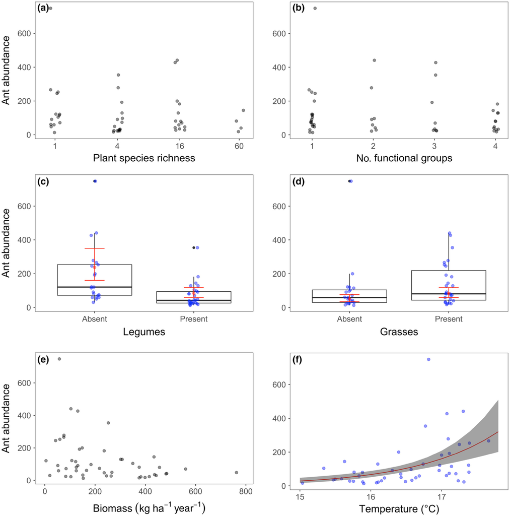

**FIGURE 1**

Open in figure viewer[PowerPoint](https://esajournals.onlinelibrary.wiley.com/action/downloadFigures?id=ecs24252-fig-0001&doi=10.1002%2Fecs2.4252)

Effect of plant species richness (a), number of functional groups (b), presence of legumes (c), presence of grasses (d), harvested plant biomass (e), and ground temperature (f) on the abundance of ants in pitfall traps during 2005. Presence of legumes and grasses are significant predictors for ant abundance. However, if temperature is included in the model, it is the only predictor variable for ant abundance (see Table 1). Significant (*p* < 0.05) relationships predicted by the negative binomial models are indicated with a solid red line.

Ant abundance decreased in the presence of legumes from an average of 127.89 workers (SE = 0.13; 95% CI: 165.01, 99.05) on plots without legumes to 59.43 workers (SE = 0.26; CI: 99.24, 35.58) on plots with legumes. This relationship held when only *L. niger* individuals were counted on pitfall traps (Appendix S1: Figure S3). When plant biomass was included in the model, the results were consistent and the presence of legumes and grasses remained as the only significant explanatory variables. The effect of these two FGs on ant abundance was ultimately mediated by temperature, which significantly increased ant abundance while the other variables, including the presence of legumes and grasses, became nonsignificant (χ<sup>2</sup> = 51.83, df = 1, *p* < 0.001) (Table 1, Figure 1).

### Colony mapping

A total of 241 nest entrances were counted, with an average of 2.97 colonies per plot (0.74 ± 0.06 colonies/m<sup>2</sup>). Plant species richness and presence of legumes decreased the number of colonies, while the number of FGs had a positive effect (Table 2, Figure 2). In the alternative model when plant biomass was included, this variable revealed a negative effect on the number of colonies (χ<sup>2</sup> = 105.90, df = 1, *p* < 0.001), and at the same time the presence of grasses became a positive predictor (χ<sup>2</sup> = 97.00, df = 1, *p* = 0.002). Noticeably, plant species richness, number of FGs, and presence of legumes did not have an effect when plant biomass was included. If temperature was used in the model, it positively affected the number of colonies (χ<sup>2</sup> = 98.51, df = 1, *p* < 0.001) while all the other variables became nonsignificant (Table 2).

TABLE 2. Results from models in which the number of colonies (Poisson errors) is evaluated based on their relationship with the predictor variables in a colony mapping grassland experiment during 2006.

| Response variable | Predictor variables | Predictors included sequentially Temp and biomass (−) Estimate | Predictors included sequentially Temp and biomass (−) *z* | Predictors included sequentially Biomass (+) Estimate | Predictors included sequentially Biomass (+) *z* | Predictors included sequentially Temp (+) Estimate | Predictors included sequentially Temp (+) *z* | Predictors included sequentially Temp and biomass (+) Estimate | Predictors included sequentially Temp and biomass (+) *z* |
| --- | --- | --- | --- | --- | --- | --- | --- | --- | --- |
| No. colonies | Intercept | **1.08** | **7.81***** | **1.59** | **8.42***** | **−6.48** | **−4.64***** | **−6.48** | **−4.64***** |
|  | Block | NS |  | **−0.13** | **−2.33*** | NS |  | NS |  |
|  | Temp | NA |  | NA |  | **0.4** | **5.48***** | **0.4** | **5.48***** |
|  | Biomass | NA |  | **−0.002** | **−4.45***** | NA |  | NS |  |
|  | PSR | **−0.22** | **−2.79**** | NS |  | NS |  | NS |  |
|  | FG | **0.3** | **3.45***** | NS |  | NS |  | NS |  |
|  | PSR × FG | NS |  | NS |  | NS |  | NS |  |
|  | Legumes | **−0.67** | **−3.92***** | NS |  | NS |  | NS |  |
|  | Grasses | NS |  | **0.39** | **2.94**** | NS |  | NS |  |

- *Note*: Models were always evaluated with the same structure (i.e., plant species richness [PSR] × functional groups [FGs] + legumes + grasses), and an additional group of variables (temperature [Temp] and biomass) was included sequentially (indicated by the symbols: + and −).
- Abbreviations: NA, not in the model; NS, not significant.
- * *p* < 0.05;
- ** *p* < 0.01;
- *** *p* < 0.001.

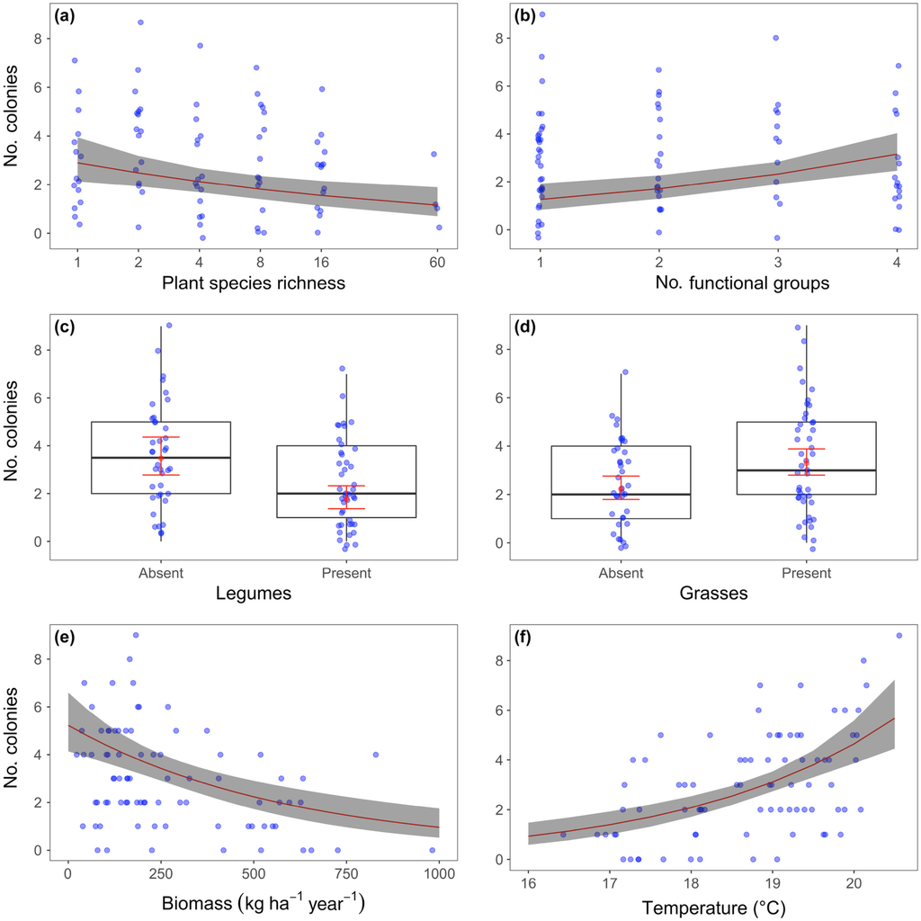

**FIGURE 2**

Open in figure viewer[PowerPoint](https://esajournals.onlinelibrary.wiley.com/action/downloadFigures?id=ecs24252-fig-0002&doi=10.1002%2Fecs2.4252)

Relationship between the number of colonies per plot in 2006 and the evaluated covariates. Plant species richness (a), functional groups (b), and presence of legumes (c) are significant predictors of number of colonies. However, when plant biomass (e) is included in the model, the effect of these three predictors disappeared while biomass itself and the presence of grasses (d) become significant. If temperature (f) is included in the model, it turned out to be the only predictor variable for number of colonies (see Table 2). Significant (*p* < 0.05) relationships predicted by the generalized linear models are indicated with a solid red line.

### Baiting experiments

#### Number of recruited ants to sugar baits (mean activity)

Across all months 11,662 individuals were recruited to sugar baits. Plant species richness interacted with the number of FGs to affect the mean activity of ants foraging on plots (*F*<sub>1,74</sub> = 4.90, *p* = 0.03) (Table 3). Changes in plant species richness did not have an effect on mean ant activity when plots maintained one FG; however, as the number of FGs increased, the effect of plant species richness on ant activity was also positive (Figure 3a). The presence of legumes positively affected the mean ant activity on sugar baits (*F*<sub>1,74</sub> = 12.60, *p* < 0.001) (Figure 3b). Once plant biomass was included in the model, it positively affected ant activity and became the only significant predictor variable (*F*<sub>1,77</sub> = 24.05, *p* < 0.001) (Table 3, Figure 3c). On the other hand, presence of grasses or temperature, when included in the model, did not show any influence on the mean ant activity in sugar baits (Appendix S1: Figure S5).

TABLE 3. Results from linear models analyzing the baiting experiment related with sugar and tuna baits (mean activity) to assess the effect of the predictor variables (i.e., plant species richness [PSR] × functional group [FG] + legumes + grasses) in a grassland experiment during 2006.

| Response variable | Predictor variables | Predictors included sequentially Temp and biomass (−) Estimate | Predictors included sequentially Temp and biomass (−) *z* | Predictors included sequentially Biomass (+) Estimate | Predictors included sequentially Biomass (+) *z* | Predictors included sequentially Temp (+) Estimate | Predictors included sequentially Temp (+) *z* | Predictors included sequentially Temp and biomass (+) Estimate | Predictors included sequentially Temp and biomass (+) *z* |
| --- | --- | --- | --- | --- | --- | --- | --- | --- | --- |
| Mean activity sugar | Intercept | **0.51** | **5.82***** | **0.28** | **6.50***** | **0.51** | **5.82***** | **0.28** | **6.50***** |
|  | Block | NS |  | NS |  | NS |  | NS |  |
|  | Temperature | NA |  | NA |  | NS |  | NS |  |
|  | Biomass | NA |  | **0.001** | **4.90***** | NA |  | **0.001** | **4.90***** |
|  | PSR | NS |  | NS |  | NS |  | NS |  |
|  | FG | **−0.14** | **−2.61*** | NS |  | **−0.14** | **−2.61*** | NS |  |
|  | PSR × FG | **0.05** | **2.21*** | NS |  | **0.05** | **2.21*** | NS |  |
|  | Legumes | **0.23** | **3.44***** | NS |  | **0.23** | **3.44***** | NS |  |
|  | Grasses | NS |  | NS |  | NS |  | NS |  |
| Mean activity tuna | Intercept | **1.81** | **5.00***** | **1.81** | **5.00***** | **−8.16** | **−3.31**** | **−8.16** | **−3.31**** |
|  | Block | NS |  | NS |  | NS |  | NS |  |
|  | Temperature | NA |  | NA |  | **0.53** | **4.16***** | **0.53** | **4.16***** |
|  | Biomass | NA |  | NS |  | NA |  | NS |  |
|  | PSR | **0.62** | **2.68**** | **0.62** | **2.68**** | **0.27** | **2.35*** | **0.27** | **2.35*** |
|  | FG | NS |  | NS |  | NS |  | NS |  |
|  | PSR × FG | **−0.19** | **2.12*** | **−0.19** | **2.12*** | NS |  | NS |  |
|  | Legumes | NS |  | NS |  | NS |  | NS |  |
|  | Grasses | **0.74** | **2.80**** | **0.74** | **2.80**** | NS |  | NS |  |

- *Note*: Furthermore, we analyzed additional predictor variables (temperature [Temp] and biomass) that were included sequentially (indicated by the symbols: + and −).
- Abbreviations: NA, not in the model; NS, not significant.
- * *p* < 0.05;
- ** *p* < 0.01;
- *** *p* < 0.001.

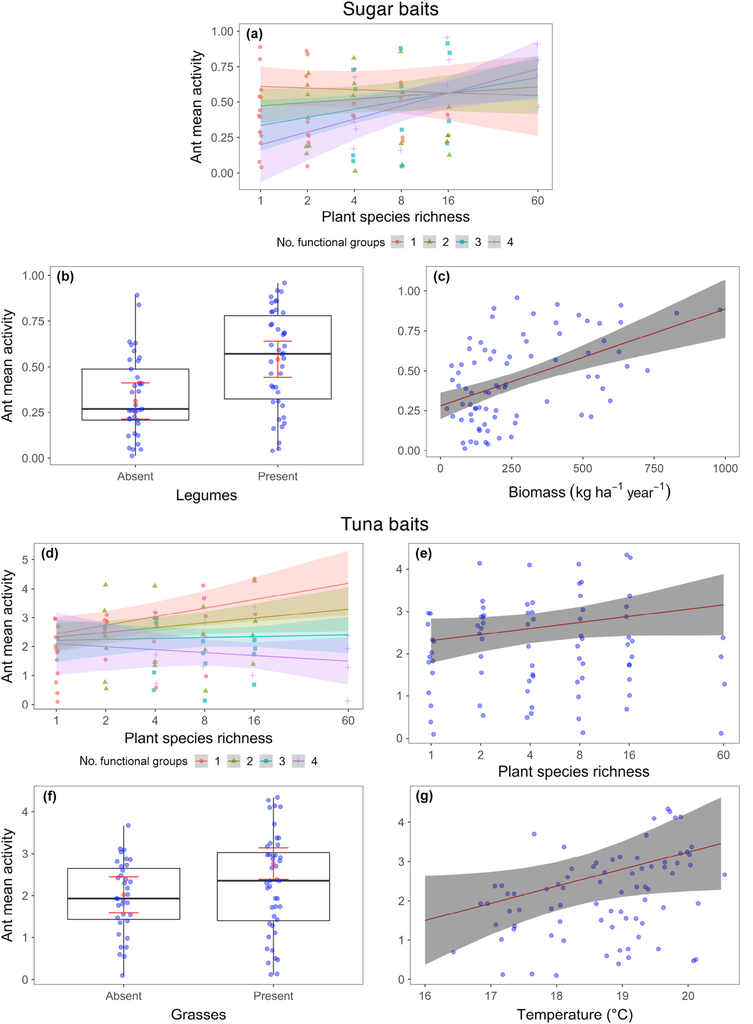

**FIGURE 3**

Open in figure viewer[PowerPoint](https://esajournals.onlinelibrary.wiley.com/action/downloadFigures?id=ecs24252-fig-0003&doi=10.1002%2Fecs2.4252)

#### Number of recruited ants to tuna baits (mean activity)

In the two tuna experiments, in total 50,276 ants were recruited to the baits. Similar to what was observed on sugar baits, the average activity in tuna baits was affected by the interaction between plant species richness and number of FGs (*F*<sub>1,74</sub> = 4.47, *p* = 0.04) (Figure 3d). There was a positive effect of plant species richness on mean ant activity when only one FG was present in the plot. The effect of plant species richness became progressively more negative when more FGs were present on the plot. Additionally, the presence of grasses also increased the mean activity of ants on tuna baits (*F*<sub>1,74</sub> = 8.03, *p* = 0.006) (Figure 3f). This result was consistent when plant biomass was included in the model, and plant biomass did not affect ant activity (Table 3; Appendix S1: Figure S6). When temperature was included in the model, this variable together with plant species richness became significant and positively affected the activity of ants on tuna baits (Table 3, Figure 3).

#### Time to first recruitment in sugar experiments

The time to first recruitment on sugar baits (mean time over the four experiments) was negatively affected by both plant species richness (*F*<sub>1,75</sub> = 10.61, *p* = 0.002) and the presence of legumes (*F*<sub>1,75</sub> = 5.93, *p* = 0.02) (Appendix S1: Table S2 and Figure S7). The other evaluated variables (i.e., FGs and the presence of grasses) did not show an effect on the time to first recruitment. Once plant biomass and temperature were included, the final models did not change and the results remained consistent.

#### Time to first recruitment in tuna experiments

We did not detect any significant variable explaining the time of first recruitment in tuna baits, as recruitment time was very short in all plots (Appendix S1: Table S2 and Figure S8).

### Plant biomass, temperature, and relative humidity were affected by plant diversity

In both years, harvested plot plant biomass increased as plant species richness increased (2005: *F*<sub>1,46</sub> = 26.87, *p* < 0.001; 2006: *F*<sub>1,76</sub> = 47.68, *p* < 0.001). The presence of legumes also increased plant biomass (2005: *F*<sub>1,46</sub> = 35.90, *p* < 0.001; 2006: *F*<sub>1,76</sub> = 37.68, *p* < 0.001) (Appendix S1: Tables S3–S4 and Figure S9).

High plant biomass in plots negatively affected soil temperature measured during the months of sampling at 5 cm depth (Appendix S1: Tables S3–S4), decreasing from an average of 18.4°C in plots with low biomass to 15.2°C in plots of high biomass (2005: *t*<sub>43</sub> = −4.36, *p* < 0.001; 2006: *t*<sub>71</sub> = −3.78, *p* < 0.001; Appendix S1: Figure S10a). Conversely, relative humidity in plots was positively affected by plant biomass (2005: *F*<sub>1,10</sub> = 20.62, *p* = 0.001; 2006: *F*<sub>1,16</sub> = 29.03, *p* < 0.001; Appendix S1: Figure S10b). Thus, increasing plant species richness decreased soil temperature and increased soil humidity by affecting plant species biomass.

Similar to plant species richness, the presence of legumes negatively affected soil temperature in both years (2005: *F*<sub>1,44</sub> = 38.40, *p* < 0.001; 2006: *F*<sub>1,72</sub> = 128.15, *p* < 0.001) (Appendix S1: Figure S11). The mean soil temperature was significantly lower in the presence of legumes (2005: 16.2 ± 0.13°C; 2006: 17.6 ± 0.17°C) compared with plots without legumes (2005: 16.9 ± 0.11°C; 2006: 19.0 ± 0.19°C) (2005: *t*<sub>44</sub> = −5.71, *p* < 0.001; 2006: *t*<sub>72</sub> = −7.54, *p* < 0.001). Humidity, on the other hand, was positively affected by the presence of legumes, but just in 2005 (*F*<sub>1,10</sub> = 6.10, *p* = 0.03) (Appendix S1: Table S3 and Figure S11).

## DISCUSSION

In this study, we analyzed the effect of plant species richness, plant functional diversity, and the presence of particular FGs on ant occurrence, number of colonies, and ant recruitment to baits in experimental grassland plots. We also explored the interaction of plant species richness with plant biomass and concomitant effects on soil temperature and aboveground relative humidity. As reported in previous studies (Marquard et al., 2009), increasing plant species richness increased plant biomass, which we found to decrease soil temperature and increase relative humidity within plots. We also found that plant diversity and particular FGs (mainly legumes) affected ant occurrence in experimental plots negatively and that these effects were mediated by aboveground plant biomass and the microclimatic conditions near the soil. Thus, fewer ant workers and number of colonies were found at lower soil temperatures and higher humidity near the ground. In contrast to most other above- and belowground arthropods (e.g., Ebeling, Hines, et al., 2018; Eisenhauer et al., 2011; Scherber et al., 2010), ants were thus negatively affected by a higher number of plant species and higher plant biomass in the experimental grasslands.

### Occurrence of ants in plots

We used both pitfall traps and colony entrance counts to investigate the occurrence of ant species on grassland plots. Pitfall trapping showed that the most abundant ant species was *L. niger* with more than 94% of all trapped individuals. While *L. niger* occurred in all plots, most ant species other than *L. niger* occurred only sporadically, and this extremely high dominance is the likely reason why we did not detect a significant effect of the variables on ant richness. *Lasius niger*, as well as many other ant species (Hölldobler & Wilson, 1990), is known as a synanthrophic ant that occurs mainly in open, grassy, warm, and dry human-affected habitats such as meadows or pastures where it can reach high densities and become dominant (Hertzog, Ebeling, et al., 2016). In temperate regions, habitats with intrinsically low diversity and with high dominance of just one or few species often feature more generalist ant species (Dauber & Wolters, 2005), which probably produces a homogenization in the structure of these communities and makes it difficult to detect differences in species richness (Dauber et al., 2006). This pattern may be particularly common in seminatural grasslands, where at large only generalist species such as *L. niger* occur and are able to establish nests in these habitats characterized by high levels of disturbance due to mowing and grazing (Dauber & Wolters, 2005), while most other ant species may show a lower level of colonization by queens in the plots or a reduced colony growth (Dauber & Wolters, 2005). It is worth noting that our survey did not estimate colony sizes and this should be a priority for future research in temperate grasslands (Wills & Landis, 2018).

Local abiotic conditions can strongly influence ant abundance (Kaspari et al., 2003). In our plots, ant abundance was predicted by the presence of particular FGs—legumes (negative) and grasses (positive effect)—and additional models accounting for temperature and plant biomass provided evidence that the underlying mechanism affecting worker numbers in ants was temperature. This result is in accordance with the pattern widely reported for ants across several ecosystems (Dunn et al., 2010), where lower temperature reduces the numbers of ground-foraging ant individuals, probably due to thermal constraints on ectotherms foraging in a seasonal environment. Two different mechanisms could explain our findings: first, due to the metabolic ecology of ectotherms (Prather et al., 2018), temperature increased the movement of workers, and thus, the probability of being captured in pitfall traps is increased when ants move faster (i.e., higher worker activity); and second, higher temperature increased brood production and population growth (Holec et al., 2006), which results in a higher number of workers per plot (i.e., higher worker number). Two lines of arguments support the hypothesis that plot differed in ant abundance rather than ant activity. First, we measured temperature at 5 cm depth every hour throughout the whole experiment, and this temperature will have a direct effect on queen and brood development; thus, our results provide evidence that grassland plots with higher temperature harbored in fact more ant workers rather than just increased worker activity. Second, the additional detailed nest sampling in plots provided further evidence that lower temperatures reduced ant abundance in plots, via lower numbers of nests. In our experiment, higher plant biomass was associated with reduced soil temperature and higher air humidity aboveground. Because increasing plant species richness, and, to a same extent, the presence of nitrogen fixing legumes increased plant biomass (Marquard et al., 2009), these variables negatively affected the number of nests in plots.

Remarkably, when plant biomass or temperature was not included in the model, the number of FGs tended to have a positive effect on the number of nests. This finding likely reflects that in more functional diverse plots, ants have access to a higher number of resources. For example, plant functional diversity increased the number of species and the abundance of arthropods (Ebeling, Rzanny, et al., 2018; Scherber et al., 2010), which can potentially serve as prey for ants. However, temperature is the factor that ultimately drives the number of nests and ant abundance in our grassland plots. This pattern may be typical for temperate grasslands and might be related with the thermophilic characteristic of ants as a taxon (Kaspari et al., 2019), which will benefit from even small increases in temperature, leading to better chances of survival, growth, and reproduction, even above the limits imposed by the plant biomass effect (a proxy for Net Primary Production - NPP) (Dunn et al., 2010; Sanders et al., 2007).

### Differential recruitment to sugar and tuna

In addition to pitfall trapping and colony counting, we carried out baiting experiments because these are useful to study patterns of ant activity (Achury et al., 2020; Prather et al., 2018). While differences in attraction between sugar and tuna were expected, there was a striking difference in sugar versus tuna recruitment, both in the number of ants observed and in the time at which the first ant appeared after bait placement. For both variables, tuna baits showed higher levels of attractiveness and were also discovered much faster, which is in accordance with the results reported in other studies (e.g., Hsu et al., 2018). Tuna baits, as opposed to sugar baits, present a strong odor, which is known to be very attractive for ants (Bestelmeyer et al., 2000). This finding might also explain the lack of significance of any of the evaluated variables for the time to first recruitment to tuna baits, where ants always found the resource within the first periods of observations.

Ants display different food requirements depending on their developmental stage, particularly larval growth and development depend on a steady supply of proteins (Davidson, 1997). In our grassland plots, for example, number of colonies and ant abundance were positively related to higher temperature, which in turn might represent larger colonies with a higher number of larvae that need proteins for their development. Ant activity on tuna baits was positively affected by soil temperature: this pattern may be a consequence of such demand for proteins to support a high number of larvae within colonies. However, as predicted by the thermal performance theory (Kaspari et al., 2019), this result where ants have higher activity on tuna baits might also be a consequence of ants foraging faster and being more active when temperature increases. To clarify this observation, further baiting experiments are required, especially because there was an additional positive effect of the number of plant species on ant activity that is not explained solely by temperature.

In regard with the time to first recruitment in sugar baits, even when plant biomass or temperature was fitted into the model, we found that the number of plant species and the presence of legumes had negative effect on the recruitment time and became the only predictor variables, suggesting further effects of plant species richness that are mediated through other factors such as vegetation complexity. In general, grassland plots with high number of plant species and presence of legumes presented a higher structural complexity, and they were likely environments in which ant workers encountered difficulties in maximizing foraging success. Habitat heterogeneity can be mediated and is closely linked with foraging strategies (Parr & Gibb, 2010), and it has been shown that for ants, especially dominant species (Sarty et al., 2006), rates and speed of discovery decrease as levels of habitat complexity increase (Wilkinson & Feener, 2007).

## CONCLUSIONS

Our study has shown that species composition and plant biomass of grasslands can strongly affect ant occurrence and activity. In the Jena biodiversity Experiment, plant species richness, plant FG richness, and the presence of legumes or grasses affected various parameters of ant establishment and foraging. These effects were clearly mediated by the effects on plant biomass, which in turn affected soil temperature and humidity. Such plant biomass effect on soil and aboveground abiotic variables has also been shown to affect other processes, such as the water cycle in plots of the Jena Experiment (Weisser et al., 2017). Our results thus show that the biotic variable plant species composition can have stronger effects on an insect group through its effect on abiotic variables (temperature, humidity) than on its effect on biotic variables (number of prey species and prey diversity). It is likely that these effects on the ant community also affect other insect groups, such as the presence of ant-tended aphids, or of preferred prey, but these effects need to be investigated in more detail (cf. Petermann et al., 2010). There were also more complex effects on ant activity as shown by the seasonally variable attractiveness of tuna and sugar baits, which we cannot fully explain yet, despite some plausible hypotheses (e.g., nutritional requirements of the colony). Understanding the effects of plant diversity on the insect community in mechanistic detail requires taking the life history of insects into account and further work is needed to link observed patterns to the biology of individual species. Such an understanding will help predict the functional consequences of changes in plant diversity with likely subsequent effects on ecosystem services provided by ants: seed dispersal, predation, and soil cycling.

## ACKNOWLEDGMENTS

We thank Yuanyuan Huang at the Centre for Integrative Biodiversity Research (iDiv), for the steady supply of data from the weather station at the field site. We also thank Pascal Edelmann for his suggestions on statistical coding. We would like to thank Norma Nitschke for her invaluable assistance with the field work. This study was supported by the German Science Foundation (DFG) through different grants to the authors. Open access funding enabled and organized by Projekt DEAL.

## CONFLICT OF INTEREST

The authors declare no conflict of interest.

[figure not shown]

[figure not shown]